# 贾耀博-2019202265

# 作业3.1.5

**将例1.1的原假设和备择假设对调，即$H_0: \lambda \leq 1 \leftrightarrow H_1: \lambda > 1$, 请选择$T=\sum\limits_{i=1}^{n} X_i$ 作为统计量，当样本$n=100$时，对拒绝域$W_1=\{T \geq 117 \}$和$W_2=\{T \geq 113\}$分别绘制势函数曲线，在犯第一、二类错误的概率相等时，给出弃权域的参数范围，比较两个检验的弃权域有怎样的分布**

## (1)

- 1. 绘制势函数曲线

```r
# 原假设空间
null_hypo_rate <- seq(0,1, by=0.02)
#备择假设空间
alter_hypo_rate <- seq(1,2, by=0.02)

# 计算第1、2类错误
typeOneError<-function (v, n){
  return (1-ppois(n, lambda = 100*v))
}

typeTwoError<-function (v, n){
  return (ppois(n, lambda = 100*v))
}

# C=117
alpha117 <- sapply(null_hypo_rate, typeOneError, n=116) #第一类错误
beta117<-sapply(alter_hypo_rate, typeTwoError, n=116) #第二类错误

#C=113
alpha113 <- sapply(null_hypo_rate, typeOneError, n=112) # 第一类错误
beta113<-sapply(alter_hypo_rate, typeTwoError, n=112) # 第二类错误

dt <-data.frame(alpha117=alpha117, beta117=beta117, alpha113=alpha113, beta113=beta113) # 构造数据框
```

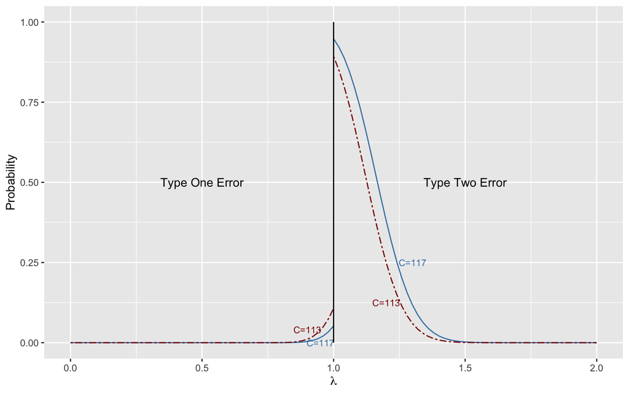

```r
library(tidyverse, quietly=T)
library(dplyr)
# 绘图
dt %>% ggplot() +
        geom_line(aes(x=null_hypo_rate, y=alpha117), color="steelblue")+
        annotate("text", x=0.95,y=0, label="C=117", color="steelblue",size=3)+
        geom_line(aes(x=null_hypo_rate, y=alpha113), color="darkred" ,linetype="twodash")+
        annotate("text", x=0.9,y=0.04, label="C=113", color="darkred",size=3)+
        geom_line(aes(x=alter_hypo_rate, y=beta117), color="steelblue")+
        annotate("text", x=1.3,y=0.25, label="C=117", color="steelblue",size=3)+
        geom_line(aes(x=alter_hypo_rate, y=beta113), color="darkred" ,linetype="twodash")+
        annotate("text", x=1.2,y=0.125, label="C=113", color="darkred",size=3)+
        geom_line(aes(x=rep(1,51), y=seq(0,1,length.out = 51)))+
        annotate("text", x=0.5,y=0.5,label="Type One Error")+
        annotate("text", x=1.5,y=0.5,label="Type Two Error")+
        xlab(expression(lambda))+
        ylab("Probability")
```

## (2)

- 2. 在犯第一、二类错误的概率相等时，给出弃权域的参数范围，比较两个检验的弃权域有怎样的分布

```r
#C=117时的犯第一类错误概率的最大值
alpha1<-1-ppois(117-1, 100)

f1<-function(lambda, n){
  return (ppois(n,100*lambda)-alpha1)
}

root<-uniroot(function (lambda) f1(lambda, 116), c(1,2))$root
cat("C=117时弃权域参数范围：(",1,",",root,")")
```

```
## C=117时弃权域参数范围：( 1 , 1.35088 )
```

```r
#C=113时的犯第一类错误概率的最大值
alpha2<-1-ppois(113-1, 100)

f2<-function(lambda, n){
  return (ppois(n,100*lambda)-alpha2)
}

root<-uniroot(function (lambda) f2(lambda, 112), c(1,2))$root
cat("C=113时弃权域参数范围：(",1,",",root,")")
```

```
## C=113时弃权域参数范围：( 1 , 1.263612 )
```

从图像中观察可以发现，在$C=113$的情况下，当样本没有落入拒绝域，而真实的$\lambda$在备择空间中。在犯第一类错误和第二类错误概率相等的时候，如果真实的$\lambda$落在这些区域中，那么犯第二类错误的范围可知，而当真实的$\lambda$在备择空间的其他位置时，犯第一类错误概率已不能等于犯第二类错误的概率，犯第二类错误的概率过高，因此在不能使两类错误概率相等时的备择假设空间中$\lambda$的范围即为弃权域，为$1<\lambda<1.26$，同理，当$C=117$时，弃权域的范围为$1<\lambda<1.35$

可以看出$C=117$比$C=113$的弃权域的范围更宽一些，这是因为C=117更倾向于支持备择假设，从极大似然角度理解，这一结果与更大的$\lambda$相对应，故出现较小的$\lambda$时，我们更有可能去不接受原假设或者放弃选择备择假设，这是合理的。